# Define the Neural Network Model

This project was conducted to strengthen my, or anyone’s, understanding of how a neural network works and especially how the back propagation actually looks like when written out by hand (or code). A simple neural network with just one hidden layer will be defined as follows

There are two input variables labeled $x_1$ and $x_2$. the three hidden nodes in the first hidden layer are $a_1$, $a_2$, $a_3$, and the output node is $\hat{y}$. The weights from the input layer to the hidden layer are labeled $w_1$ with a bias term of $b_1$. This is then passed through an activation function (Relu) for the final result of the first hidden layer. With these results, the weights from the hidden layer to the output layer are $w_2$ with a bias term of $b_2$ which is passed through another activation function(sigmoid) to reach its final value $\hat{y}$.

**Neural Network Model visualized**

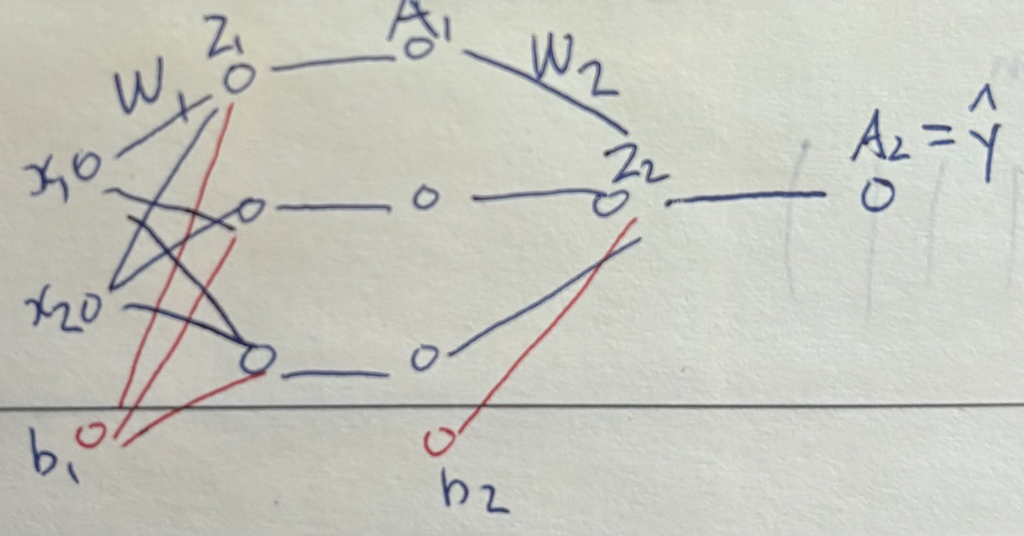

**Equation for Neural Network**

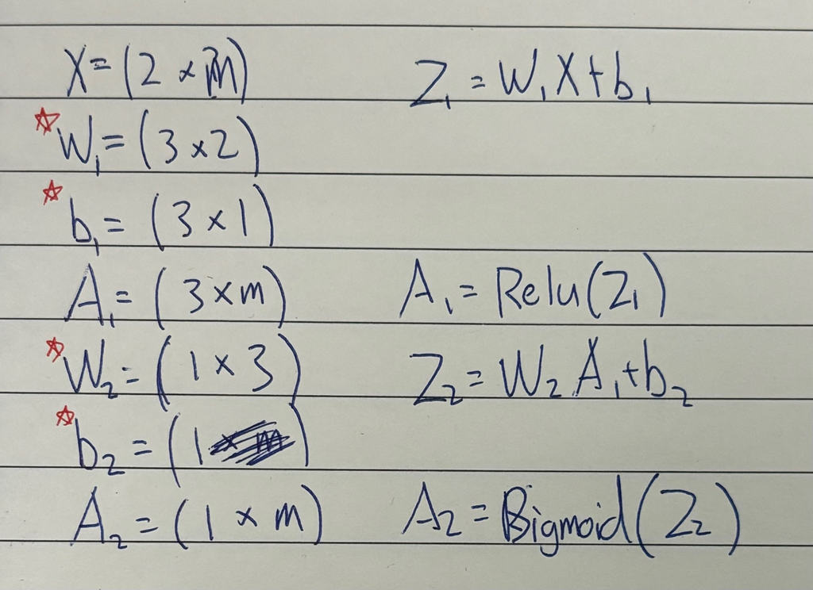

within this image, m represents the number of input data points. $x$ does not mean that there are two data points, but there are two features of m number of data points that will be put into the model. since there are m number of data points, the output also has 1 x m number of outputs

```python
# code-fold: True
#| code-summary: "Import Packages"
import numpy as np
import matplotlib.pyplot as plt
from sklearn.datasets import make_classification
from sklearn.metrics import confusion_matrix
```

## Initializing Parameters

The goal of neural networks is to start the model with almost a random guess and move towards the direction and value where the cost funciton is minimized. We will set a funciton to initialize a random set of parameters according to the shape decribed in the section above.

```python
# code-fold: False
#| code-summary: "Initialize Parameters"
def init_params():
    W1 = np.random.uniform(-1,1,6).reshape(2,-1)
    b1 = np.random.uniform(-1,1,3).reshape(3,-1)
    W2 = np.random.uniform(-1,1,3).reshape(3,-1)
    b2 = np.random.uniform(-1,1,1).reshape(1,-1)
    return W1,b1,W2,b2
```

## Utility Functions

In order to train our model, it would be convenient to create some funcitons that will be used throughout the process.

```python
def sigmoid(x):
    """
    Sigmoid funciton
    """
    return 1 / (1 + np.exp(-x))

def sigmoid_derivative(x):
    """
    The derivative of the sigmoid funciton for back propagation
    """
    return sigmoid(x) * (1 - sigmoid(x))

def relu(x):
    """
    The Relu Function
    """
    return np.maximum(0, x)

def relu_derivative(Z):
    """
    The derivative of the relu funciton for back propagation
    """
    return Z > 0

def mse_loss(y_hat, y):
    """
    The loss funciton is 0.5 multiplied the SSR.
    0.5 is multiplied for simplicity of calculation when calculating the derivative.
    """
    cost = 0.5 * np.sum((y_hat - y)**2)
    return cost
```

## Feed Forward Function

This function is a simple function which takes all the parameters and input matrix to retrieve the prediction of the model.

```python
def forward_pass(W1, b1, W2, b2, X):
    """
    W1: Weights for input layer → hidden layer
    b1: Bias terms for input layer → hidden layer
    W2: Weights for hidden layer → final prediction
    b2: Bias terms for hidden layer → final prediction
    """
    z1 = W1.T @ X + b1
    a = relu(z1)
    z2 = W2.T @ a + b2
    y_hat = sigmoid(z2)
    return z1, z2, a, y_hat
```

## Back Propagation

The back propagation is the part that was the most difficult to understand. Basically we find the partial derivative of each parameter in relationto the loss function. Therefore, in this case we need to find the derivative for $W_{1}$, $b_{1}$, $W_{2}$, $b_{2}$. We do this by using the chain rule. The equations for A and Z are described in the image above. It’s not described in the image, but its important to divide the partial derivatives by m(number of input data points). This is because during the process of matrix multiplicaiton, the output of the partial derivatives are the result of the sum of m number of data points. To find the average effect each variable has on the loss funciton, we need to divide the derivative by m.

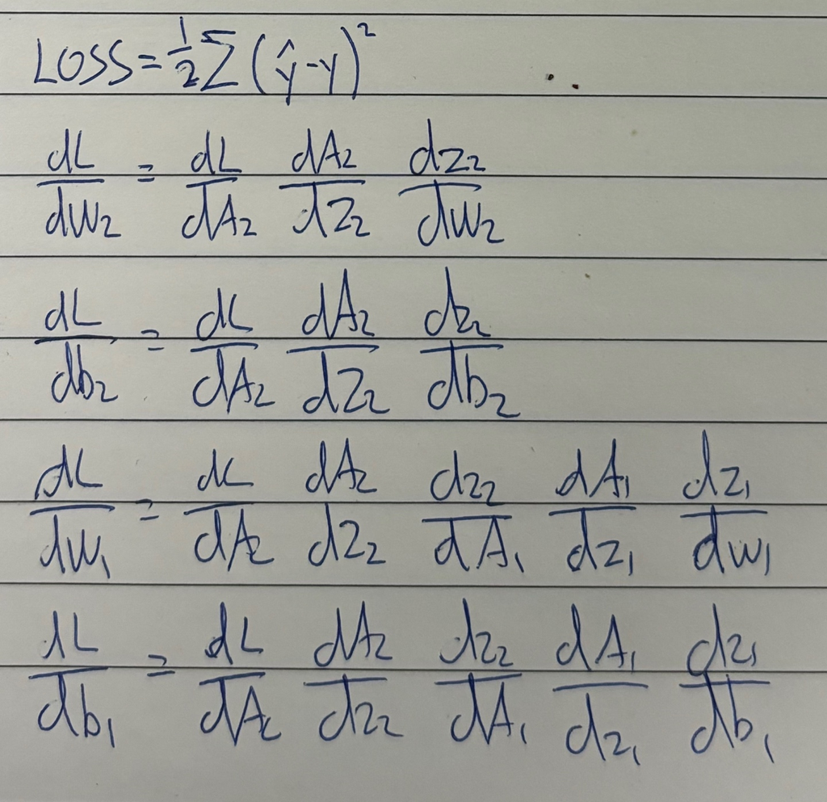

```python
def grad_f(W1, b1, W2, b2, X, y):
    m = X.shape[1]  # Number of data points
    z1, z2, a, y_hat = forward_pass(W1, b1, W2, b2, X)

    # Compute gradients for Loss Function
    """
    The derivative of the loss function in relation to y_hat is (y_hat-y)
    Other than the derivative mentioned above, all the partial derivatives
    are calculated by the premade functions, or are the input parameters.

    In some cases, the order of multiplication may not be in the exact order of
    how the partial derivatives were calculated by hand in the image above, but
    this is because of the dimensions of matrix multiplication. When you calculate
    your partial derivative, the order may be different from mine depending on
    how the initial parameters are shaped and whether you transposed the matricies.
    The important part is that all parts of the partial derivative listed in the
    equations above are present in the code below.
    """
    dv = 1/m * ((y_hat-y)*(sigmoid_derivative(z2))).dot(a.T)
    dc = np.mean(((y_hat-y)*(sigmoid_derivative(z2))))
    dW = 1/m*((W2@((y_hat-y)*(sigmoid_derivative(z2))))*relu_derivative(z1)).dot(X.T)
    db = np.mean(((W2@((y_hat-y)*(sigmoid_derivative(z2))))*relu_derivative(z1)),axis=1)

    return dW, db, dv, dc
```

## Generate Dataset

We will generate a dataset with two features and 400 data points for our simple neural net to train on.

```python
import numpy as np
import matplotlib.pyplot as plt
from sklearn.datasets import make_classification

X, y = make_classification(
    n_samples=400,  # Total number of samples
    n_features=2,   # Number of features
    n_informative=2,
    n_redundant=0,
    n_clusters_per_class=1,
    flip_y=0.1,
    class_sep=1.5,   # Controls the margin between classes
    random_state=42
)
X = X.T
y = y.reshape(1,-1)

m = X.shape[1]
```

## Training the model

The logic of neural networks is that it creates an output by forwarding its inputs and calculates the cost. Then, the partial derivative of each parameter in respect to the cost is calculated to see how the change of each parameter effects the cost. Then we shift each parameter by the gradient(direction) multiplied by the given learning rate to find new parameters and input these into the model once again. This process is repeated until the cost is lower than a given tolerance level or when the iterations reach the maximum interations that we defined as hyperparameters of the model.

**Define function to train model according to learning rate, max iterations, tolerance**

```python
def fit_model_grad(W,b,v,c,X,y, LR = 0.01, max_iter = 1000000, tolerance = 0.000001):
    loss = []
    for i in range(max_iter):

        # Use the pre-made function to find partial derivatives of all parameters
        dW, db, dv, dc = grad_f(W,b,v,c,X,y)

        # Update parameters by multiplying gradients by learning rate and shifting the original parameters.
        W -= dW.T * LR
        b -= db.reshape(-1,1) * LR
        v -= dv.T * LR
        c -= dc * LR

        # Feed the updated parameters into the model for a new predictions
        z1, z2, a, y_hat = forward_pass(W,b,v,c,X)

        # Calculate the cost of the new predictions
        cost = mse_loss(y_hat,y)

        # Append the cost into a blank list to graph for later use
        loss.append(cost)

        # Stop function if cost is less than tolerance level
        if cost < tolerance:
            print("End training : loss less than tolerance level")
            return W,b,v,c,y_hat
            break
    return W,b,v,c,y_hat,loss
```

```python
# Initialize parameters
W,b,v,c = init_params()

# Fit model to find optimal parameters
W,b,v,c,y_hat,loss = fit_model_grad(W,b,v,c,X,y, LR = 0.01, max_iter = 10000, tolerance = 0.000001)

# Feed optimal parameters into model
_,_,_, y_hat = forward_pass(W,b,v,c,X)

# The y_pred is an output if decimals form 0 to 1 due to the sigmoid funciton.
# To match this with the original y values, we will change the values form 0 to 1 with a threshold of 0.5
y_pred = [0 if i < 0.5 else 1 for i in y_hat.flatten()]
```

## Evaluation(Confusion Matirx / Plotting loss function)

```
Confusion Matrix
[[175  26]
 [ 20 179]]
```

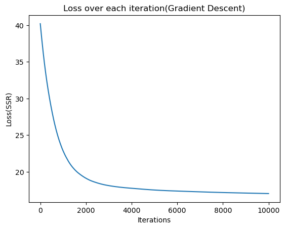

```python
from sklearn.metrics import confusion_matrix

# Calculate the confusion matrix
cm = confusion_matrix(y.flatten(), y_pred)

print("Confusion Matrix")
print(cm)
print("")

plt.plot(loss)
plt.title('Loss over each iteration(Gradient Descent)')
plt.xlabel('Iterations')
plt.ylabel('Loss(SSR)')
plt.show()
```

## Train another model with momentum (not gradient descent)

The difference between using gradient descent and momentum is that momentum is able to control the speed of how fast the model learns along the iterations. For example, by using the momentum, we will be able to decrease the cost faster in the earlier iterations, and after a certain point, decrease the learning speed. This is shown in the plot of cost throughout iterations below.

```python
def fit_model_mom(W, b, v, c, X, y, LR=0.01, momentum=0.9, max_iter=1000000, tolerance=0.000001):
    loss = []

    # Initialize velocities
    vW, vb, vv, vc = 0, 0, 0, 0

    for i in range(max_iter):
        dW, db, dv, dc = grad_f(W, b, v, c, X, y)

        # Update velocities using momentum
        vW = momentum * vW - LR * dW.T
        vb = momentum * vb - LR * db.reshape(-1, 1)
        vv = momentum * vv - LR * dv.T
        vc = momentum * vc - LR * dc

        # Update parameters with momentum
        W += vW
        b += vb
        v += vv
        c += vc

        z1, z2, a, y_hat = forward_pass(W, b, v, c, X)

        cost = mse_loss(y_hat, y)
        loss.append(cost)

        if cost < tolerance:
            print("End training: loss less than tolerance level")
            return W, b, v, c, y_hat

    print(cost)
    return W, b, v, c, y_hat, loss
```

```
15.444888878643415
[[179  22]
 [ 16 183]]
```

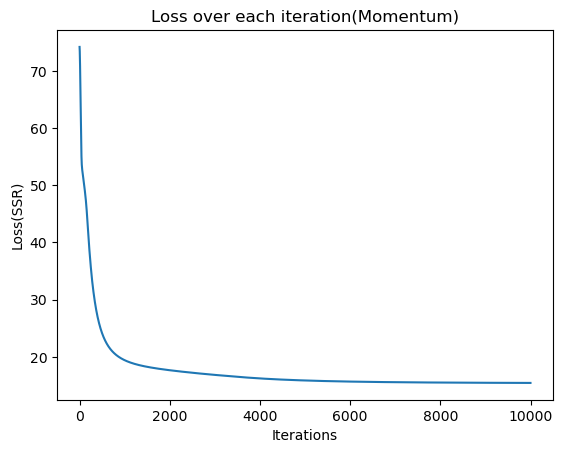

```python
W,b,v,c = init_params()
W,b,v,c,y_hat,loss = fit_model_mom(W,b,v,c,X,y, LR = 0.01, max_iter = 10000, tolerance = 0.000001)

_,_,_, y_hat = forward_pass(W,b,v,c,X)
y_pred = [0 if i < 0.5 else 1 for i in y_hat.flatten()]


from sklearn.metrics import confusion_matrix

# Calculate the confusion matrix
cm = confusion_matrix(y.flatten(), y_pred)

print(cm)

plt.plot(loss)
plt.title('Loss over each iteration(Momentum)')
plt.xlabel('Iterations')
plt.ylabel('Loss(SSR)')
plt.show()
```

# Conclusion

Through this mini-project, we explored how a neural network utilizes back propagation to optimize its parameters. The model tweaks its parameters little by little by calculating the gradient in respect to the loss function. We explored how the chain rule was utilized to find the gradient for each parameter and how the shape of the matricies were aligned to calculate the gradient. Furthermore, we took a quick look at how momentum could be used in place of gradient descent and how it could be effective due to its flexibility in learning rate.